# Project: European Soccer Database Analysis.

### Research Question 3: Which team has the biggest performance change over the time period?

By counting wins for each team in each season, we compare max wins and min wins and compute the difference, the one with biggest difference has the biggest performance change over years.

```python
# Look at the team match dataset.
match_new_df.head(1)
```

|  | country_id | season | stage | date | match_api_id | home_team_api_id | away_team_api_id | home_team_goal | away_team_goal |
| --- | --- | --- | --- | --- | --- | --- | --- | --- | --- |
| 0 | 1 | 2008/2009 | 1 | 2008-08-17 | 492473 | 9987 | 9993 | 1 | 1 |

```python
# Calculate the result for home team in form of win, loose or draw.
match_new_df.loc[match_new_df['home_team_goal'] > match_new_df['away_team_goal'],'home_outcome']='w'
match_new_df.loc[match_new_df['home_team_goal'] == match_new_df['away_team_goal'],'home_outcome']='d'
match_new_df.loc[match_new_df['home_team_goal'] < match_new_df['away_team_goal'],'home_outcome']='l'
```

[output not shown]

```python
# Calculate the result for away team in form of win, loose or draw.
match_new_df.loc[match_new_df['home_team_goal'] > match_new_df['away_team_goal'],'away_outcome']='l'
match_new_df.loc[match_new_df['home_team_goal'] == match_new_df['away_team_goal'],'away_outcome']='d'
match_new_df.loc[match_new_df['home_team_goal'] < match_new_df['away_team_goal'],'away_outcome']='w'
```

[output not shown]

```python
# Keep only required columns in home and away team dataframe.
df_match_home=match_new_df.loc[:,('country_id', 'season', 'stage', 'date', 'match_api_id', 'home_team_api_id', 'home_outcome')]
df_match_away=match_new_df.loc[:,('country_id', 'season', 'stage', 'date', 'match_api_id', 'away_team_api_id', 'away_outcome')]

# Rename the required columns.
df_match_home.rename(index=str,columns={'home_team_api_id':'team_api_id','home_outcome':'outcome'},inplace=True)
df_match_away.rename(index=str,columns={'away_team_api_id':'team_api_id','away_outcome':'outcome'},inplace=True)

# Concat both the dataframes into one.
df_match_outcome=pd.concat([df_match_home,df_match_away])
df_match_outcome.head()
```

|  | country_id | season | stage | date | match_api_id | team_api_id | outcome |
| --- | --- | --- | --- | --- | --- | --- | --- |
| 0 | 1 | 2008/2009 | 1 | 2008-08-17 | 492473 | 9987 | d |
| 1 | 1 | 2008/2009 | 1 | 2008-08-16 | 492474 | 10000 | d |
| 2 | 1 | 2008/2009 | 1 | 2008-08-16 | 492475 | 9984 | l |
| 3 | 1 | 2008/2009 | 1 | 2008-08-17 | 492476 | 9991 | w |
| 4 | 1 | 2008/2009 | 1 | 2008-08-16 | 492477 | 7947 | l |

```python
# Unique number of teams.
df_match_outcome.team_api_id.nunique()
```

```
299
```

```python
### Now cleaning the team table
# Droping column id,team_fifa_api_id as it is of no use.
team_df.drop(['id','team_fifa_api_id'],axis=1,inplace=True)
```

```python
# Merge match outcome and team dataframe.
team_match = df_match_outcome.merge(team_df,how='inner',on='team_api_id')
team_match.head(1)
```

|  | country_id | season | stage | date | match_api_id | team_api_id | outcome | team_long_name | team_short_name |
| --- | --- | --- | --- | --- | --- | --- | --- | --- | --- |
| 0 | 1 | 2008/2009 | 1 | 2008-08-17 | 492473 | 9987 | d | KRC Genk | GEN |

```python
# Get all the matches with outcome as win.
team_win = team_match.query('outcome == "w"')

# Now trim the dataset as per the requirements.
team_win_count = team_win.loc[:,('season','match_api_id','team_long_name','outcome')]

# Groupby team name and season and count the wins season wise.
team_win_count = team_win.groupby(['team_long_name','season'])['match_api_id'].agg({'count'}).reset_index()
team_win_count.head(1)
```

|  | team_long_name | season | count |
| --- | --- | --- | --- |
| 0 | 1. FC Kaiserslautern | 2010/2011 | 13 |

```python
# Groupby team name and season and calculate min and max wins.
team_win_count2 = team_win_count.groupby(['team_long_name'])['count'].agg({'max','min'}).reset_index().sort_values(['max','min'],ascending=False)
team_win_count2.head(1)
```

|  | team_long_name | max | min |
| --- | --- | --- | --- |
| 133 | Juventus | 33 | 15 |

```python
# Find difference between max and min.
team_win_count2['diff'] = team_win_count2['max'] - team_win_count2['min']
```

```python
# Sort the values according to the difference.
team_win_count2.sort_values(['diff'],ascending=False,inplace=True)
team_win_count2.head()
```

|  | team_long_name | max | min | diff |
| --- | --- | --- | --- | --- |
| 133 | Juventus | 33 | 15 | 18 |
| 186 | Paris Saint-Germain | 30 | 12 | 18 |
| 165 | Montpellier Hérault SC | 25 | 8 | 17 |
| 100 | FC Zürich | 24 | 7 | 17 |
| 246 | Sporting CP | 27 | 11 | 16 |

[output not shown]

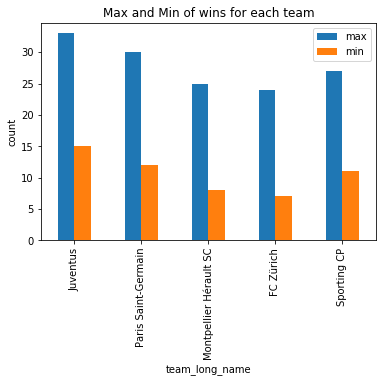

```python
#plot max and min in bar chart.
team_win_count2.head(5).plot.bar(x='team_long_name',y=['max','min'],title='Max and Min of wins for each team')
plt.ylabel('count');
```

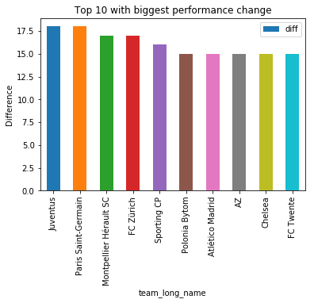

```python
# Plotting difference of each team.
team_win_count2.head(10).plot.bar(x='team_long_name',y='diff',title='Top 10 with biggest performance change');
plt.ylabel('Difference');
```

### Research Question 4: Among three personality attributes: potential,stamina, and agreesion, which player attributes lead to the hgiher overall rating?

```python
# Look at the player's attributes dataset.
player_attributes_df.head(1)
```

|  | id | player_fifa_api_id | player_api_id | date | overall_rating | potential | preferred_foot | attacking_work_rate | defensive_work_rate | crossing | finishing | heading_accuracy | short_passing | volleys | dribbling | curve | free_kick_accuracy | long_passing | ball_control | acceleration | sprint_speed | agility | reactions | balance | shot_power | jumping | stamina | strength | long_shots | … |
| --- | --- | --- | --- | --- | --- | --- | --- | --- | --- | --- | --- | --- | --- | --- | --- | --- | --- | --- | --- | --- | --- | --- | --- | --- | --- | --- | --- | --- | --- | --- |
| 0 | 1 | 218353 | 505942 | 2016-02-18 00:00:00 | 67.0 | 71.0 | right | medium | medium | 49.0 | 44.0 | 71.0 | 61.0 | 44.0 | 51.0 | 45.0 | 39.0 | 64.0 | 49.0 | 60.0 | 64.0 | 59.0 | 47.0 | 65.0 | 55.0 | 58.0 | 54.0 | 76.0 | 35.0 | … |

```python
# Trim the dataset and get the required columns only.
ratings = player_attributes_df.loc[:,('overall_rating','potential','stamina','aggression')]
ratings.head()
```

|  | overall_rating | potential | stamina | aggression |
| --- | --- | --- | --- | --- |
| 0 | 67.0 | 71.0 | 54.0 | 71.0 |
| 5 | 74.0 | 76.0 | 79.0 | 68.0 |
| 38 | 65.0 | 67.0 | 66.0 | 60.0 |
| 64 | 69.0 | 69.0 | 49.0 | 70.0 |
| 87 | 70.0 | 70.0 | 60.0 | 66.0 |

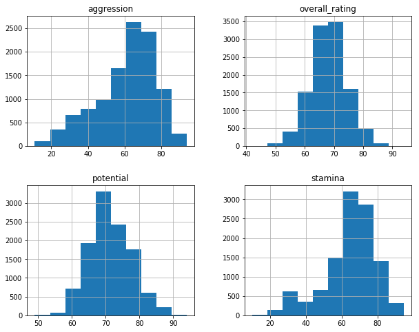

```python
# view distribution of data.
ratings.hist(figsize=(10,8));
```

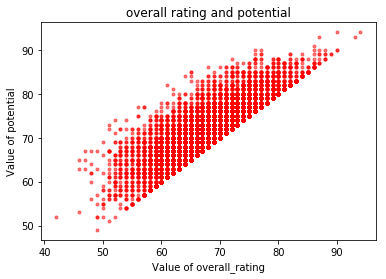

```python
# plot overall_rating and potential to see if there is correlation between the two factors.

plt.plot( 'overall_rating', 'potential', data=ratings, linestyle='', marker='o', markersize=3, alpha=0.5, color="red")

# Titles.
plt.xlabel('Value of overall_rating')
plt.ylabel('Value of potential')
plt.title('overall rating and potential');
```

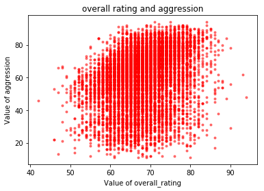

```python
# plot overall_rating and aggression to see if there is correlation between the two factors.
plt.plot( 'overall_rating', 'aggression', data=ratings, linestyle='', marker='o', markersize=3, alpha=0.5, color="red")

# Titles.
plt.xlabel('Value of overall_rating')
plt.ylabel('Value of aggression')
plt.title('overall rating and aggression');
```

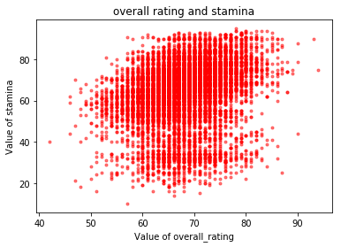

```python
# plot overall_rating and stamina to see if there is correlation between the two factors.
plt.plot( 'overall_rating', 'stamina', data=ratings, linestyle='', marker='o', markersize=3, alpha=0.5, color="red")

# Titles.
plt.xlabel('Value of overall_rating')
plt.ylabel('Value of stamina')
plt.title('overall rating and stamina');
```

ANSWER

> We can clearly see that the correlation between potential and overall ratings is very strong. As the potential of the player increases the overall ratings also increases. It suggests that the potential is the key contributing factor of players overall success.

> The correlation between stamina and overall rating is postive but not strong. It suggests that stamina factor should be used cautiously when evaluating player's overall rating.

> The correlation between aggression and overall rating is postive but not strong. It suggests that aggresion factor should be used cautiously when evaluating player's overall rating

```python
from subprocess import call
call(['python', '-m', 'nbconvert', 'Investigate_a_Dataset.ipynb'])
```

```
0
```